# Reproducible Research: Peer Assessment 1

## Loading and preprocessing the data

```r
activity <- read.csv("~/activity.csv")
```

## What is mean total number of steps taken per day?

- Calculate the total number of steps taken per day

```r
totstep.per.day <- tapply(activity$steps,activity$date,sum,na.rm = T)
```

- Make a histogram of the total number of steps taken per day

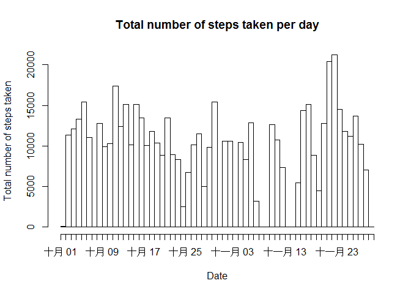

```r
hist.data1 <- c()
for(i in 1:length(totstep.per.day)){
    if(totstep.per.day[i]!=0)
        hist.data1 <- c(hist.data1,rep(names(totstep.per.day)[i],totstep.per.day[i]))
}
hist.data1 <- as.Date(hist.data1)
dates <- as.Date(unique(activity$date))
hist(hist.data1,ylab = "Total number of steps taken",xlab = "Date",breaks = dates,freq = T,main = "Total number of steps taken per day")
```

- Calculate and report the mean and median of the total number of steps taken per day

```r
summary(totstep.per.day)
```

```
##    Min. 1st Qu.  Median    Mean 3rd Qu.    Max.
##       0    6778   10400    9354   12810   21190
```

So,the mean is **9354** , median is **10400** .

## What is the average daily activity pattern?

- Make a time series plot (i.e. type = “l”) of the 5-minute interval (x-axis) and the average number of steps taken, averaged across all days (y-axis)

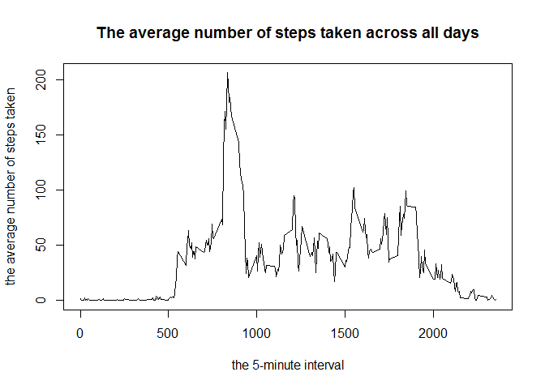

```r
avg.step.inv <- tapply(activity$steps,activity$interval,mean,na.rm =T)
plot(x = names(avg.step.inv),y = avg.step.inv,type = "l",xlab = "the 5-minute interval",ylab = "the average number of steps taken", main = "The average number of steps taken across all days")
```

- Which 5-minute interval, on average across all the days in the dataset, contains the maximum number of steps?

```r
max.inv <- names(avg.step.inv)[which.max(avg.step.inv)]
max.inv
```

```
## [1] "835"
```

The 5-minute interval contains the maximum number of steps, on average across all the days in the dataset, is **835** .

## Imputing missing values

- Calculate and report the total number of missing values in the dataset (i.e. the total number of rows with NAs)

```r
summary(activity)
```

```
##      steps                date          interval
##  Min.   :  0.00   2012-10-01:  288   Min.   :   0.0
##  1st Qu.:  0.00   2012-10-02:  288   1st Qu.: 588.8
##  Median :  0.00   2012-10-03:  288   Median :1177.5
##  Mean   : 37.38   2012-10-04:  288   Mean   :1177.5
##  3rd Qu.: 12.00   2012-10-05:  288   3rd Qu.:1766.2
##  Max.   :806.00   2012-10-06:  288   Max.   :2355.0
##  NA's   :2304     (Other)   :15840
```

It’s obviously that “steps” is only field which contains NAs, and the total number of rows with NAs is 2304.

- Use the mean for that 5-minute interval for filling in all of the missing values in the dataset.Create a new dataset that is equal to the original dataset but with the missing data filled in.

```r
na.ind <- which(is.na(activity$steps))
na.inv <- activity$interval[na.ind]
temp <- match(na.inv,names(avg.step.inv))
activity.new <- activity
activity.new$steps[na.ind] <- avg.step.inv[temp]
summary(activity.new)
```

```
##      steps                date          interval
##  Min.   :  0.00   2012-10-01:  288   Min.   :   0.0
##  1st Qu.:  0.00   2012-10-02:  288   1st Qu.: 588.8
##  Median :  0.00   2012-10-03:  288   Median :1177.5
##  Mean   : 37.38   2012-10-04:  288   Mean   :1177.5
##  3rd Qu.: 27.00   2012-10-05:  288   3rd Qu.:1766.2
##  Max.   :806.00   2012-10-06:  288   Max.   :2355.0
##                   (Other)   :15840
```

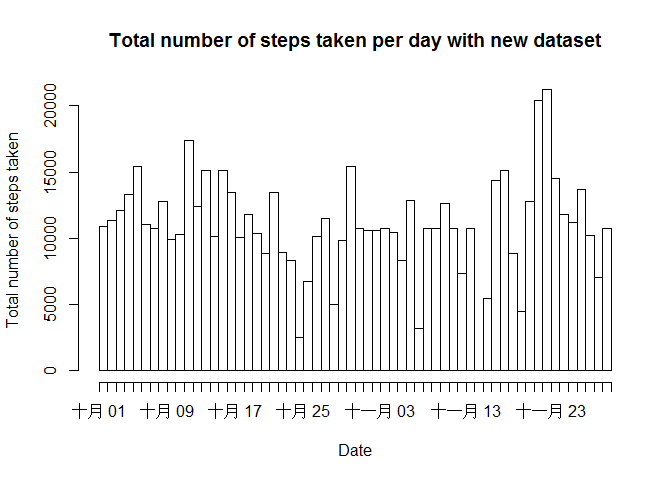

```r
totstep.per.day.n <- tapply(activity.new$steps,activity.new$date,sum,na.rm = T)
hist.data2 <- c()
for(i in 1:length(totstep.per.day.n)){
    if(totstep.per.day.n[i]!=0)
        hist.data2 <- c(hist.data2,rep(names(totstep.per.day.n)[i],totstep.per.day.n[i]))
}
hist.data2 <- as.Date(hist.data2)
hist(hist.data2,ylab = "Total number of steps taken",xlab = "Date",breaks = dates,freq = T,main = "Total number of steps taken per day with new dataset")
```

```r
meanstep.per.day.n <- round(mean(totstep.per.day.n,na.rm = T ),4)
medianstep.per.day.n <- round(median(totstep.per.day.n,na.rm = T),4)
```

## Are there differences in activity patterns between weekdays and weekends?

For this part Use the dataset with the filled-in missing values for this part.

- Create a new factor variable in the dataset with two levels – “weekday” and “weekend” indicating whether a given date is a weekday or weekend day.

```r
week <- weekdays(as.Date(activity.new$date))
week[which(week %in% c("星期一","星期二","星期三","星期四","星期五"))] <- "weekday"
week[which(week %in% c("星期六","星期日"))] <- "weekend"
activity.new$isweekday <- factor(week,level = c("weekday","weekend"))
```

- Make a panel plot containing a time series plot (i.e. type = “l”) of the 5-minute interval (x-axis) and the average number of steps taken, averaged across all weekday days or weekend days (y-axis). See the README file in the GitHub repository to see an example of what this plot should look like using simulated data.

[figure not shown]

```r
temp1 <- which(activity.new$isweekday == "weekday")
temp2 <- which( activity.new$isweekday == "weekend")
avg.step.inv.wd <- tapply(activity.new$steps[temp1],activity$interval[temp1],mean,na.rm =T)
avg.step.inv.we <- tapply(activity.new$steps[temp2],activity$interval[temp2],mean,na.rm =T)
avg.weekday <- data.frame(inv = names(avg.step.inv.wd),
                          avg = avg.step.inv.wd,
                          is.weekday = "weekday")
avg.weekend <- data.frame(inv = names(avg.step.inv.we),
                          avg = avg.step.inv.we,
                          is.weekday = "weekend")
avg.week <- rbind(avg.weekday,avg.weekend)
avg.week <- avg.week[order(avg.week$is.weekday,avg.week$inv),]
library(lattice)
xyplot(avg ~ inv | is.weekday,data = avg.week,type = "l",,layout=c(1,2),xlab = "the 5-minute interval",ylab = "the average number of steps taken")
```